# 🚑 **NLP PROJECT 1** 🚑

# *Information Retrieval Challenge*

**Maud Tissot & Aurelien Pouxviel**

# **SUMMARY**

## **1 Presentation of the problem and the dataset**

- 1.1 Objective
- 1.2 Presentation of the dataset

## **2 Explaination of the raw algorithm**

## **3 Text processing & tokenization**

- 3.1 - Final processing method
- 3.2 - Most used words
- 3.3 - Links and adresses

## **4 Embeddings on words**

- 4.1 - All methods
- 4.3 - TF-IDF embeddings
- 4.4 - Word2Vec embeddings
- 4.5 - FastText embeddings (tensorflow projector)

## **5 Embeddings on documents and requests**

- 5.1 - All methods
- 5.2 - Fast text embeddings
- 5.3 - Sbert embeddings

## **6 Evaluating our models**

- 6.1 Method
- 6.2 evaluate with different processing
- 6.2 evaluate with different embeddings

## **7 User trial**

(*Bert , Supervised approach*)

```python
# https://docs.google.com/presentation/d/1uBTHmUp6jj5LA-CkqGlxO7JeDjr98kPzoprBG6y3Vrk/edit#slide=id.g1bc94aa34b6_0_0
```

# ----------------------------------

```python
!pip install rank_bm25
#!pip install plotly

#Vizu
import matplotlib.pyplot as plt
import plotly.graph_objects as go
import matplotlib.pyplot as plt
import plotly.express as px

#google collab
import shutil
from google.colab import files

#data
from collections import defaultdict
import string
import numpy as np
import os
import pandas as pd

#token and text processing
import nltk
from nltk.tag import pos_tag
from nltk.corpus import stopwords
from nltk.tokenize import word_tokenize
from nltk.stem import WordNetLemmatizer
nltk.download('stopwords')
nltk.download('punkt')
nltk.download('wordnet')

#embedings
import tensorflow as tf
from tensorboard.plugins import projector
from sklearn.manifold import TSNE
from sklearn.cluster import KMeans
from sklearn.preprocessing import StandardScaler
from sklearn.feature_extraction.text import TfidfVectorizer
from gensim.models import Word2Vec
from gensim.models import KeyedVectors
from gensim.models.fasttext import FastText
!pip install sentence-transformers
from sentence_transformers import SentenceTransformer


#model
import rank_bm25
from rank_bm25 import BM25Okapi
from sklearn.metrics import ndcg_score
import random

#score
from sklearn.metrics.pairwise import cosine_similarity
from tqdm import tqdm
```

```
     ━━━━━━━━━━━━━━━━━━━━━━━━━━━━━━━━━━━━━━━━ 86.0/86.0 kB 1.4 MB/s eta 0:00:00
  Preparing metadata (setup.py) ... done
     ━━━━━━━━━━━━━━━━━━━━━━━━━━━━━━━━━━━━━━━━ 1.3/1.3 MB 6.9 MB/s eta 0:00:00
```

# ----------------------------------

## **1 Presentation of the problem and the dataset**

The goal of the project is to develop our own information retrieval system on a specific corpus. In order to do that, we are allowed to use any kind of pre-treatment and manipulate the vocabulary of the documents.

The dataset is a medical corpus. The document are abstracts of medical publication from PubMed and the queries are scraps of vulgarisation on the topics linked to some PubMed articles. It’s a very complex corpus where modern deep learning approaches fail to perform better than BM25.

### **1.1 - Presentation of the dataset**

```python
!pip install rank_bm25
!git clone https://github.com/cr-nlp/project1-2023.git

def load_doc(filename,dic=defaultdict(dict),reqdoc=False):
	with open(filename) as file:
		lines = file.readlines()
	for line in lines:
		tabLine = line.split('\t')
		if reqdoc:
			req = tabLine[0]
			doc = tabLine[2]
			dic[req][doc]=int(tabLine[3])
		else:
			key = tabLine[0]
			value = tabLine[1]
			dic[key] = value
	return dic

def loadNFCorpus():
	dicDoc    = load_doc("./project1-2023/dev.docs",{})
	dicReq    = load_doc("./project1-2023/dev.all.queries",{})
	dicReqDoc = load_doc("./project1-2023/dev.2-1-0.qrel",defaultdict(dict),True)
	return dicDoc,dicReq,dicReqDoc
```

```
Cloning into 'project1-2023'...
remote: Enumerating objects: 8, done.
remote: Counting objects: 100% (8/8), done.
remote: Compressing objects: 100% (6/6), done.
remote: Total 8 (delta 0), reused 0 (delta 0), pack-reused 0
Receiving objects: 100% (8/8), 2.30 MiB | 4.93 MiB/s, done.
```

```python
dicDoc,dicReq,dicReqDoc = loadNFCorpus()

print("_______Documents______\n")
print(dicDoc.keys())
print("len :",len(dicDoc.keys()))
print("\n_______Requests______\n")
print(dicReq.keys())
print("len : ",len(dicReq.keys()))
print("\n_______Requests and Documents______\n")
print(dicReqDoc.keys())
```

```
_______Documents______

dict_keys(['MED-118', 'MED-329', 'MED-330', 'MED-332', 'MED-334', 'MED-335', 'MED-398', 'MED-557', 'MED-666', 'MED-691', 'MED-692', 'MED-706', 'MED-707', 'MED-708', 'MED-709', 'MED-711', 'MED-712', 'MED-713', 'MED-714', 'MED-716', 'MED-717', 'MED-718', 'MED-719', 'MED-720', 'MED-721', 'MED-722', 'ME…
len : 3193

_______Requests______

dict_keys(['PLAIN-1', 'PLAIN-1007', 'PLAIN-101', 'PLAIN-1017', 'PLAIN-1027', 'PLAIN-1038', 'PLAIN-1049', 'PLAIN-1065', 'PLAIN-1077', 'PLAIN-1087', 'PLAIN-1097', 'PLAIN-11', 'PLAIN-1108', 'PLAIN-111', 'PLAIN-1118', 'PLAIN-1129', 'PLAIN-1140', 'PLAIN-1150', 'PLAIN-1160', 'PLAIN-1171', 'PLAIN-1181', 'P…
len :  325

_______Requests and Documents______

dict_keys(['PLAIN-1', 'PLAIN-11', 'PLAIN-22', 'PLAIN-32', 'PLAIN-43', 'PLAIN-55', 'PLAIN-67', 'PLAIN-77', 'PLAIN-90', 'PLAIN-101', 'PLAIN-111', 'PLAIN-122', 'PLAIN-132', 'PLAIN-142', 'PLAIN-152', 'PLAIN-164', 'PLAIN-174', 'PLAIN-185', 'PLAIN-195', 'PLAIN-206', 'PLAIN-216', 'PLAIN-226', 'PLAIN-237', …
```

```python
print(dicDoc["MED-118"])
```

```
alkylphenols human milk relations dietary habits central taiwan pubmed ncbi abstract aims study determine concentrations num nonylphenol np num octylphenol op num human milk samples examine related factors including mothers demographics dietary habits women consumed median amount cooking oil signifi…
```

```python
print(dicReq["PLAIN-1"])
```

```
why deep fried foods may cause cancer in the latest study on dietary patterns and breast cancer risk among women , healthier eating was associated with eliminating three-quarters of the odds of breast cancer , whereas less healthy eating was associated with up to nearly eight times the odds . includ…
```

```python
print(dicReqDoc["PLAIN-1"])
```

```
{'MED-2421': 2, 'MED-2422': 2, 'MED-2416': 2, 'MED-2423': 2, 'MED-2417': 2, 'MED-2418': 2, 'MED-4451': 2, 'MED-2420': 2, 'MED-2414': 1, 'MED-4070': 1, 'MED-3498': 1, 'MED-2424': 1, 'MED-2426': 1, 'MED-2674': 1, 'MED-2675': 1, 'MED-2676': 1, 'MED-2677': 1, 'MED-2678': 1, 'MED-2679': 1, 'MED-4037': 1,…
```

These dictionaries contain information about the documents, queries, and their associations:

- dicDoc:

This dictionary contains information about medical documents. Each key represents a document ID (e.g., 'MED-118', 'MED-329'). The corresponding values are the text content of the documents.

- dicReq:

This dictionary appears to contains simplifications of previous articles. Each key represents a query ID (e.g., 'PLAIN-901', 'PLAIN-912').

- dicReqDoc (defaultdict of dictionaries):

This dictionnary corresponds to associations between several Medicine documents and one simplification. The numerical value may indicate some form of relevance or weight.(e.g., {'PLAIN-901' : {'MED-2421 ':2 ... }...)

## **2 Explaination of the raw algorithm**

We created definitions to explain the code given in the project

We've broken down the example code into several functions to make it easier to understand.

The run_bm25_only method returns a score to evaluate the information retrieval between a request and many scientific articles. Inside :

- loadNFCorpus : loads the data in three different dictionaries
- selectNb : Select a number of request to reduce the amount of data
- getAllVocab : Return for each document two list of all the vocabulary present in the documents and in the requests
- getTokenDoc : Return each documents to a token
- getTokenReq : Same for requests
- bm25_ngcd : Initiate a bm25 model using bm25 Okapi and the list of documents. Then calculate a list of score for each request. The score should be high if the documents correspond to the request. Finally ndcg score evaluate the quality of the results. Here is an example:
  - bm25score = [0.9 , 0.01 , 0.8, 0,2...]
  - trueDoc = [ 1. , 0 , 1 , 0 ...]
  - => here the ndcg score should by high beacause high probabilities are associated to true documents (1) and low to documents that doesn't correspond to the request (0)

```python
def text2TokenList(text,l=[]):
  stopword = stopwords.words('english')
  word_tokens = word_tokenize(text.lower())
  word_tokens_without_stops = [word for word in word_tokens if word not in stopword and len(word)>2]
  return word_tokens_without_stops

def selectNb(dictRD,start,end):
  doc, docReq = [], defaultdict(dict)
  i = start
  for r in dictRD:
    if i > (end - i) :
      break
    for d in dictRD[r]:
      docReq[r][d] = dictRD[r][d]
      doc.append(d)
      i = i + 1
  req = list(docReq.keys())
  doc = list(set(doc))
  return docReq, doc, req

def getAllVocab(document,ids):
  vocab = {}
  for id in ids:
    words = text2TokenList(document[id])
    for w in words:
      if w not in vocab:
        vocab[w] = w
  return list(vocab)

def getTokenDoc(ids,documents):
  tokenList, tokenId, tokenId_NB   = [], [], {}
  i = 0
  for id in ids:
    token = text2TokenList(documents[id])
    tokenList.append(token)
    tokenId.append(id)
    tokenId_NB[id] = i
    i = i + 1
  return tokenList, tokenId,tokenId_NB

def getTokenReq(ids,documents):
  tokenList,tokenId, tokenId_NB = {}, [], {}
  i = 0
  for id in ids:
    token = text2TokenList(documents[id])
    tokenList[id] = token
    tokenId.append(id)
    tokenId_NB[id] = i
    i = i + 1
  return tokenList,tokenId, tokenId_NB

def getTrueDocs(len_,req,corpusDicoDocName,dicReqDocToKeep):
  true = np.zeros(len_)
  for docId in corpusDicoDocName:
    if req in dicReqDocToKeep:
      if docId in dicReqDocToKeep[req]:
        pos       = corpusDicoDocName[docId]
        true[pos] = dicReqDocToKeep[req][docId]
  return true

def bm25_ngcd(ndcgTop, reqTokens,reqDocs, docTokens, docIndices):
  bm25 = BM25Okapi(docTokens)
  ndcg, nbReq = 0, 0

  for r in reqTokens:
    doc_scores = bm25.get_scores(reqTokens[r])
    trueDocs   = getTrueDocs(len(docTokens),r,docIndices,reqDocs)
    ndcg       = ndcg + ndcg_score([trueDocs], [doc_scores],k=ndcgTop)
    nbReq      = nbReq + 1
  return ndcg / nbReq


def ndgcScore_bm25(startDoc,endDoc,ndcgTop=5):
  allDoc, allReq, allReqDoc = loadNFCorpus()
  #_____________SELECT INFO___________________
  reqDocs, docs, reqs = selectNb(allReqDoc,startDoc,endDoc)
  #____________ALL VOCAB DOC & REQ_____________
  allVocabListDoc = getAllVocab(allDoc,docs)
  allVocabListReq = getAllVocab(allReq,reqs)
  #_____________TOKENISE DOC & REQ______________
  docTokens, docNames , docIndices = getTokenDoc(docs,allDoc)
  reqTokens, reqNames , reqIndices = getTokenReq(reqs,allReq)
  #_______________EVALUATE SCORE________________
  mean_ndcgBM25 = bm25_ngcd(ndcgTop, reqTokens,reqDocs, docTokens, docIndices)
  return mean_ndcgBM25
```

```python
nb_docs = 200
print("Average ndcg score : ",ndgcScore_bm25(0,nb_docs))
```

```
Average ndcg score :  0.8072123842662229
```

## **3 Text pre-processing**

### **3.1 - Methods**

- stopwords, <2
- link and adresses
- lem
- delWords

```python
def tokenizeDoc(text,delWords=[],lem=False,link=True):
  stopword = stopwords.words('english')
  token = word_tokenize(text.lower())
  token = [word for word in token if word not in stopword and len(word)>2]
  if link:
    token = [word for word in token if not any(char in word for char in [".", "-", "/","\\n","@","html","<",">"])] #delete link and adresse
  if lem:
    lemmatizer = WordNetLemmatizer()
    token = [lemmatizer.lemmatize(word) for word in token]
  if len(delWords)>0:
    token = [word for word in token if word not in delWords]
  return token
```

```python
ex = dicDoc['MED-118']
print("Nb of words :",len(ex.split(" ")))
print("Basics processings : ",len(tokenizeDoc(ex,link=False,lem=False)))
print("Delete links       : ",len( tokenizeDoc(ex,link=True,lem=True)))
print("Delete num word    : ",len(tokenizeDoc(ex,delWords=["num"],lem=True,link=False)))
print("Delete links and num word : ",len(tokenizeDoc(ex,delWords=["num"],link=True,lem=True)))
print("Final processing :",tokenizeDoc(ex,delWords=["num"],link=True,lem=True))
```

```
Nb of words : 118
Basics processings :  111
Delete links       :  108
Delete num word    :  95
Delete links and num word :  92
Final processing : ['alkylphenols', 'human', 'milk', 'relation', 'dietary', 'habit', 'central', 'taiwan', 'pubmed', 'ncbi', 'abstract', 'aim', 'study', 'determine', 'concentration', 'nonylphenol', 'octylphenol', 'human', 'milk', 'sample', 'examine', 'related', 'factor', 'including', 'mother', 'demog…
```

### **3.2 - Most used words / delWords**

```python
def AllVocab(document,lem=False,link=True):
  vocab = {}
  for id in document:
    words = tokenizeDoc(document[id],lem=lem,link=link)
    for w in words:
      if w not in vocab:
        vocab[w] = 1
      else:
        vocab[w] = vocab[w]+1
  return vocab

def showAllVocab(sorted_dic,a=0,b=50):
  keys   = list(sorted_dic.keys())
  values = list(sorted_dic.values())
  freq   = np.round(values/np.sum(values)*100,3)
  print(f"Nombre de mots            : {np.sum(values)}")
  print(f"Nombre de mots différents : {len(keys)}\n")
  fig = go.Figure()
  fig.add_trace(go.Bar(x=keys[a:b],y=freq[a:b], marker=dict(color=freq[a:b], colorscale='Viridis', showscale=True)))
  fig.update_xaxes(tickangle=45)
  fig.update_layout(
      title=f"Frequence des mots entre {a} et {b} en %",
      xaxis_title='Catégories',
      yaxis_title='Valeurs',)
  fig.show()
  print(f"Ces {b-a} mots representent {np.round(np.sum(values[a:b])*100/np.sum(values))}% du nombre de mots dans les documents et seulement {np.round((b-a)*100/len(keys),2)}% des mots différents")

def delWords(document,n=15,lem=False):
  vocab = AllVocab(dicDoc,lem)
  vocab = dict(sorted(vocab.items(), key=lambda item: item[1],reverse=True))
  return list(vocab.keys())[:n]
```

```python
# Documents
allVocabListDoc = AllVocab(dicDoc)
sortedDoc = dict(sorted(allVocabListDoc.items(), key=lambda item: item[1],reverse=True))

allVocabListDocLem = AllVocab(dicDoc,lem=True)
sortedDocLem = dict(sorted(allVocabListDocLem.items(), key=lambda item: item[1],reverse=True))

#Requests
allVocabListReq = AllVocab(dicReq)
sortedReq = dict(sorted(allVocabListReq.items(), key=lambda item: item[1],reverse=True))

allVocabListReqLem = AllVocab(dicReq,lem=True)
sortedReqLem = dict(sorted(allVocabListReqLem.items(), key=lambda item: item[1],reverse=True))
```

```python
print("_____All documents words______\n\n")
showAllVocab(sortedDoc,0,100)
print ("\n\n______Documents words without num______\n\n")
showAllVocab(sortedDoc,1,100)
print("\n\n______Documents words lemmatized______\n\n")
showAllVocab(sortedDocLem,1,100)
```

```
_____All documents words______


Nombre de mots            : 440443
Nombre de mots différents : 20964
```

[interactive chart not shown]

```
Ces 100 mots representent 32.0% du nombre de mots dans les documents et seulement 0.48% des mots différents


______Documents words without num______


Nombre de mots            : 440443
Nombre de mots différents : 20964
```

[interactive chart not shown]

```
Ces 99 mots representent 23.0% du nombre de mots dans les documents et seulement 0.47% des mots différents


______Documents words lemmatized______


Nombre de mots            : 440443
Nombre de mots différents : 18905
```

[interactive chart not shown]

```
Ces 99 mots representent 26.0% du nombre de mots dans les documents et seulement 0.52% des mots différents
```

```python
print("_____All requests words______\n\n")
showAllVocab(sortedReq,0,100)
print("\n\n______Requests words lemmatized______\n\n")
showAllVocab(sortedReqLem,0,100)
```

```
_____All requests words______


Nombre de mots            : 303277
Nombre de mots différents : 22116
```

[interactive chart not shown]

```
Ces 100 mots representent 25.0% du nombre de mots dans les documents et seulement 0.45% des mots différents


______Requests words lemmatized______


Nombre de mots            : 303277
Nombre de mots différents : 19878
```

[interactive chart not shown]

```
Ces 100 mots representent 27.0% du nombre de mots dans les documents et seulement 0.5% des mots différents
```

NB : We also showed the interest of lemmatization

```python
l1 = delWords(dicDoc,lem=True,n=20)
l2 = delWords(dicReq,lem=True,n=50)
print("list of words to delete in documents")
print(l1)
print("list of words to delete in Requests")
print(l2)
```

```
list of words to delete in documents
['num', 'study', 'risk', 'abstract', 'cancer', 'intake', 'effect', 'diet', 'pubmed', 'ncbi', 'food', 'disease', 'dietary', 'result', 'patient', 'level', 'consumption', 'group', 'cell', 'human']
list of words to delete in Requests
['num', 'study', 'risk', 'abstract', 'cancer', 'intake', 'effect', 'diet', 'pubmed', 'ncbi', 'food', 'disease', 'dietary', 'result', 'patient', 'level', 'consumption', 'group', 'cell', 'human', 'woman', 'health', 'year', 'factor', 'concentration', 'association', 'increased', 'total', 'acid', 'conclu…
```

```python
#l2_thuned_lem = ['diet', 'food', 'video', 'study', 'one', 'would', 'like', 'health', 'people', 'eat', 'get', 'http', 'also', 'may', 'much', 'eating', 'dr.', 'plant', 'good',  'year', 'know', 'animal', 'day', 'see', 'time', 'make', 'think', 'even', 'greger', 'whole', 'many', 'high', 'level', 'risk', 'could', 'well', 'need', 'effect', 'way', 'say', 'found', 'based', 'healthy', 'low', 'take', 'better', 'really', 'help', 'thing', 'product', 'work', 'cause', 'still', 'great', 'want', 'find', 'lot', 'best', 'source', 'thanks', 'intake', 'question', 'use', 'le', 'problem', 'supplement', 'research', 'nutritionfacts.org','amount', 'article', 'since',  'might', 'human', 'point', 'green', 'doctor', 'two', 'please', 'look', 'read', 'grain', 'information', 'every', 'thank', 'juice', 'increase', 'benefit', 'bad', 'keep', 'back', 'free', 'post', 'feel', 'evidence', 'long', 'result', 'fact', 'used', 'type' 'actually', 'first', 'though', 'sure', 'lower', 'check', 'right', 'show', 'try', 'per', 'comment', 'seems', 'without', 'something', 'mean', 'another', 'going', 'issue', 'little', 'enough', 'made', 'site', 'higher', 'science', 'come', 'change', 'part', 'thought', 'etc','link', 'week', 'reason', 'give', 'new', 'associated', 'different', 'raw', 'love', 'said', 'maybe', 'never', 'example', 'important', 'last', 'number', 'getting', 'book', 'coffee', 'however', 'month', 'always']
```

```python
#l1_thunes = ['num', 'study', 'risk', 'abstract', 'cancer', 'intake', 'effect', 'diet', 'pubmed', 'ncbi', 'food', 'disease', 'dietary', 'result', 'patient', 'level', 'consumption', 'group', 'cell', 'human', 'woman', 'health', 'year', 'factor', 'concentration', 'association', 'increased', 'total', 'acid', 'conclusion', 'significantly', 'control', 'method', 'data', 'exposure', 'significant', 'high', 'compared', 'activity', 'treatment', 'subject', 'protein', 'age', 'trial', 'increase', 'higher', 'men', 'breast', 'analysis', 'meat', 'lower', 'blood', 'sample', 'diabetes', 'evidence', 'product', 'child', 'mortality', 'clinical', 'case', 'serum', 'objective', 'found', 'fat', 'weight', 'type', 'cardiovascular', 'healthy', 'vegetable', 'antioxidant', 'potential', 'review', 'fruit', 'cholesterol', 'population', 'plasma', 'time', 'vitamin', 'fish', 'body', 'low', 'background', 'function', 'participant', 'day', 'observed', 'including', 'adult', 'intervention', 'week', 'ratio', 'animal', 'difference', 'rate', 'response', 'reduction', 'death', 'vegetarian', 'prevalence', 'individual', 'model', 'role', 'cohort', 'reduced', 'showed', 'symptom', 'placebo', 'finding', 'present', 'mechanism', 'incidence', 'reported', 'lipid', 'baseline', 'insulin', 'related', 'suggest', 'source', 'research', 'obesity', 'milk', 'number', 'content', 'daily', 'decreased', 'lifestyle', 'state', 'test', 'compound', 'index', 'measured', 'glucose', 'score', 'period', 'major', 'fatty', 'randomized', 'design', 'important', 'drug', 'outcome', 'month', 'assessed', 'benefit', 'prevention', 'chronic', 'development', 'copyright', 'included', 'extract', 'curcumin', 'prospective', 'plant', 'pattern', 'based', 'growth', 'interval', 'infection', 'examined', 'identified', 'tissue', 'highest', 'consumed', 'exercise', 'energy', 'oil', 'determine', 'similar', 'tea', 'measure', 'decrease', 'greater', 'stress', 'system', 'trend', 'meal', 'juice', 'normal', 'common', 'recent', 'quality', 'condition', 'reduce', 'questionnaire', 'follow-up', 'relationship', 'confidence', 'physical', 'change', 'supplementation', 'pressure', 'estimate', 'frequency', 'event', 'relative', 'conducted', 'supplement', 'positive', 'investigated', 'elsevier']
#Not enough med voc
```

### **3.3 - Effect of processing**

Looking at the embeddings visualization we realised that many links or caracters remained, we can detect them with the following caracters : . / ...

```python
# Documents
allVocDoc             = AllVocab(dicDoc,lem=False,link=False)
allVocDocLem          = AllVocab(dicDoc,lem=True,link=False)
allVocDocLemNolink    = AllVocab(dicDoc,lem=True,link=True)
#allVocDocLemNolinkdel = AllVocab(dicDoc,lem=True,link=True,delWords=[])

#Requests
allVocReq          = AllVocab(dicReq,lem=False,link=False)
allVocReqLem       = AllVocab(dicReq,lem=True,link=False)
allVocReqLemNolink = AllVocab(dicReq,lem=True,link=True)
#allVocReqLemNolinkdel = AllVocab(dicReq,lem=True,link=True,delWords=[])
```

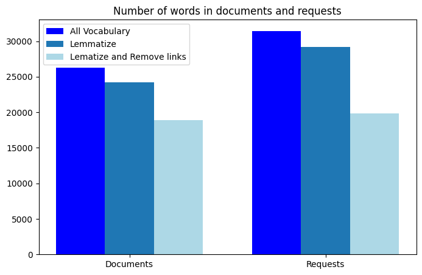

```python
allVoc          = [len(allVocDoc.keys()), len(allVocReq.keys())]
allVocLem       = [len(allVocDocLem.keys()), len(allVocReqLem.keys())]
allVocLemNolink = [len(allVocDocLemNolink.keys()), len(allVocReqLemNolink.keys())]

fig = plt.figure(figsize=(8,5))
width=0.25
positions_allVoc = np.arange(len(allVoc))
positions_allVocLem = [p+width for p in positions_allVoc]
positions_allVocLemNolink = [p+width for p in positions_allVocLem]

plt.bar(positions_allVoc, allVoc, width=width, color="blue", label='All Vocabulary')
plt.bar(positions_allVocLem, allVocLem, width=width, color="tab:blue", label='Lemmatize')
plt.bar(positions_allVocLemNolink, allVocLemNolink, width=width, color="lightblue", label='Lematize and Remove links')

plt.xticks([0.25,1.25], ['Documents', 'Requests'])
plt.title('Number of words in documents and requests')
plt.legend()
plt.show()
```

## **4 Embeddings on words**

```python
allDoc, allReq, allReqDoc = loadNFCorpus()
sampleDoc = list(allDoc.values())[:8]
sampleReq = list(allReq.values())[:1]

lDelDoc = delWords(allDoc,lem=True,n=30) #essayer plus tard /thuner
lDelReq = delWords(allReq,lem=True,n=30) #essayer plus tard
```

### **4.1 - All methods**

```python
#TFIDF
def allWords(documents,delWords=[],lem=False,link=True):
  words = []
  for doc in documents:
    words.extend(tokenizeDoc(doc,delWords=delWords,lem=lem,link=link))
  return words

def tfidfVector(document,delWords=[],lem=False,link=True):
  all_words = allWords(document,delWords=delWords,lem=lem,link=link)
  tfidf_vectorizer = TfidfVectorizer()
  tfidf_matrix = tfidf_vectorizer.fit_transform(all_words)
  tfidf_embeddings = tfidf_matrix.toarray()
  return tfidf_embeddings

#word2Vector
def word2Vector(document, delWords=[], lem=False, link=True):
    all_words = allWords(document, delWords, lem)
    model = Word2Vec(sentences=[all_words], vector_size=100, window=5, min_count=1, sg=0)
    vectors = model.wv
    model.wv.save_word2vec_format("word2vec.model")
    word2vec_array = np.array([vectors[word] for word in all_words if word in vectors.index_to_key])
    return word2vec_array, model

#fastText
def fastText(document,delWords=[],lem=False,link=True):
    all_words = allWords(document,delWords,lem,link)
    fasttext_model = FastText(sentences=[all_words], vector_size=100, window=5, min_count=1, workers=4, epochs=20)
    fasttext_emb = np.array([fasttext_model.wv[word] for word in all_words])
    return fasttext_emb

#Visualize with TSNE
def tsneViz(embeddings, method, perplexity=30, allWords=None, num_clusters=5):
    tsne = TSNE(n_components=3, random_state=42, perplexity=perplexity)
    embeddings_tsne = tsne.fit_transform(embeddings)
    # Apply K-Means clustering
    kmeans = KMeans(n_clusters=num_clusters, random_state=42)
    clusters = kmeans.fit_predict(embeddings)
    # Create a DataFrame for Plotly
    df = pd.DataFrame(embeddings_tsne, columns=['Dim1', 'Dim2', 'Dim3'])
    df['Word'] = allWords
    df['Cluster'] = clusters.astype(str)  # Convert cluster labels to string for categorical coloring
    fig = px.scatter_3d(df, x='Dim1', y='Dim2', z='Dim3', text='Word',
                        color='Cluster', title=f"{method} Embeddings - 3D t-SNE Visualization with Clusters",
                        hover_name='Word', hover_data={'Word': True, 'Cluster': True})
    fig.update_traces(marker=dict(size=5))
    fig.show()
```

The principle of t-SNE (t-distributed Stochastic Neighbor Embedding) is a dimension reduction technique used in data analysis. A key parameter, called "perplexity," is used to balance the observation of the overall and local structure of the data during reduction. Perplexity measures the extent to which the probability distribution in the reduced dimension reflects that of the original dimension. Low perplexity focuses on the local details of the data, while high perplexity promotes a more global representation to maintain the structure of the original dataset, thereby offering a better overall representation of the data.

### **4.2 - TF-IDF embeddings**

```python
#Get labels
all_wordsDoc = allWords(sampleDoc,delWords=lDelDoc,lem=True,link=True)
all_wordsReq = allWords(sampleReq,delWords=lDelReq,lem=True,link=True)
#Create embeddings
doc_emb2d = tfidfVector(sampleDoc,delWords=lDelDoc,lem=True,link=True)
req_emb2d = tfidfVector(sampleReq,delWords=lDelReq,lem=True,link=True)
```

```python
print("\n______Document embeddings______\n")
tsneViz(doc_emb2d, "TF-IDF", perplexity=30, allWords=all_wordsDoc, num_clusters=7)

print("\n_____Request embeddings______\n")
tsneViz(req_emb2d, "TF-IDF", perplexity=30, allWords=all_wordsReq, num_clusters=7)
```

```
______Document embeddings______
```

[interactive chart not shown]

```
_____Request embeddings______
```

[interactive chart not shown]

Applying a k-means algorithm for clustering on TF-IDF did not yield satisfactory results. The 3D clustering loses a significant amount of information. Therefore, we will explore alternative methods of tf-idf

### **4.3 - Word2Vec embeddings**

```python
word2vec_arrayDoc,wod2vecModelDoc  = word2Vector(sampleDoc,delWords=lDelDoc,lem=True,link=True)
word2vec_arrayReq,wod2vecModelReq  = word2Vector(sampleReq,delWords=lDelReq,lem=True,link=True)
```

```python
print("\n______Document embeddings______\n")
tsneViz(word2vec_arrayDoc, "Word2Vec", allWords=all_wordsDoc, perplexity=30, num_clusters=5)

("\n______Request embeddings______\n")
tsneViz(word2vec_arrayReq, "Word2Vec", allWords=all_wordsReq, perplexity=30, num_clusters=5)
```

```
______Document embeddings______
```

[interactive chart not shown]

[interactive chart not shown]

Last for Word2Vec : Tensorflow Projector

```python
current_directory = os.getcwd()
files_in_directory = os.listdir(current_directory)
print("Current Directory:", current_directory)
print("Files in Current Directory:", files_in_directory)
!python -m gensim.scripts.word2vec2tensor -i ./word2vec.model -o /content/my_model
files.download("/content/my_model_tensor.tsv")
files.download("/content/my_model_metadata.tsv")
```

```
Current Directory: /content
Files in Current Directory: ['.config', 'word2vec.model', 'project1-2023', 'sample_data']
2023-11-19 15:01:59,807 - word2vec2tensor - INFO - running /usr/local/lib/python3.10/dist-packages/gensim/scripts/word2vec2tensor.py -i ./word2vec.model -o /content/my_model
2023-11-19 15:01:59,808 - keyedvectors - INFO - loading projection weights from ./word2vec.model
2023-11-19 15:01:59,889 - utils - INFO - KeyedVectors lifecycle event {'msg': 'loaded (592, 100) matrix of type float32 from ./word2vec.model', 'binary': False, 'encoding': 'utf8', 'datetime': '2023-11-19T15:01:59.887135', 'gensim': '4.3.2', 'python': '3.10.12 (main, Jun 11 2023, 05:26:28) [GCC 11.4…
2023-11-19 15:01:59,973 - word2vec2tensor - INFO - 2D tensor file saved to /content/my_model_tensor.tsv
2023-11-19 15:01:59,973 - word2vec2tensor - INFO - Tensor metadata file saved to /content/my_model_metadata.tsv
2023-11-19 15:01:59,973 - word2vec2tensor - INFO - finished running word2vec2tensor.py
```

1 -> Launch https://projector.tensorflow.org/  
2 -> Load tensor and meta data downloaded local

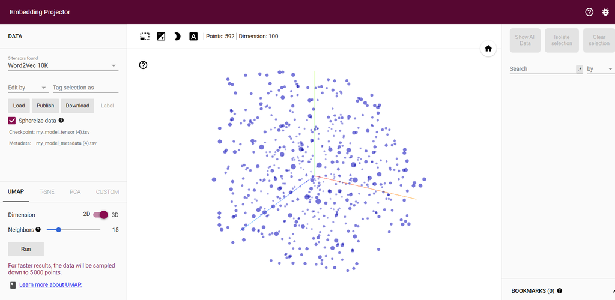

### **4.3 - Fast text embeddings**

```python
#Get labels
#all_wordsDoc = allWords(sampleDoc,delWords=lDelDoc,lem=True,link=True)
#all_wordsReq = allWords(sampleReq,lem=True)
#embeddings
fastTextEmbeddingDoc = fastText(sampleDoc,delWords=lDelDoc,lem=True,link=True)
fastTextEmbeddingReq = fastText(sampleReq,delWords=lDelReq,lem=True,link=True)
```

```python
print("\n______Document embeddings______\n")
tsneViz(fastTextEmbeddingDoc, "FastText", perplexity=30, allWords=all_wordsDoc, num_clusters=5)

print("\n______Request embeddings______\n")
tsneViz(fastTextEmbeddingReq, "FastText", perplexity=30, allWords=all_wordsReq, num_clusters=5)
```

```
______Document embeddings______
```

[interactive chart not shown]

```
______Request embeddings______
```

[interactive chart not shown]

## **5 Embeddings on document**

```python
sampleDoc,names = [],[]
for r in list(dicReqDoc.keys())[:150:15]:
  for d in dicReqDoc[r].keys():
    names.extend([r])
    sampleDoc.extend([dicDoc[d]])
```

```python
print("len sample of documents :",len(names))
```

```
len sample of documents : 297
```

### **5.1 - All methods**

```python
#fast text
def train_fasttext_model(corpus, model_path, dim=100, epoch=5):
    model = FastText(sentences=corpus, vector_size=dim, epochs=epoch)
    model.save(model_path)
    return model

def fasttext_embedding(tokens, model):
    embeddings = [model.wv[token] for token in tokens if token in model.wv]
    return np.mean(embeddings, axis=0) if embeddings else np.zeros(model.vector_size)

def fastTextDoc(document, delWords=[], lem=False, link=True):
    doc  = [tokenizeDoc(doc,delWords=delWords,lem=lem,link=link) for doc in document]
    embeddings_list = []
    model = train_fasttext_model(doc, 'fasttext_model.model')
    for doc_tokens in doc:
      req_embedding = fasttext_embedding(doc_tokens, model)
      embeddings_list.append(req_embedding)
    return np.array(embeddings_list), model

#sbert
def sbertDoc(document, model):
    doc = [tokenizeDoc(doc, delWords=[], lem=True, link=True) for doc in document]
    embeddings_list = []
    for doc_tokens in doc:
        req_embedding = model.encode(" ".join(doc_tokens))
        embeddings_list.append(req_embedding)
    return np.array(embeddings_list), model

#Visualize with TSNE
def tsneVizDoc(embeddings, method, perplexity=30, requestNames=None):
    tsne = TSNE(n_components=3, random_state=42, perplexity=perplexity)
    embeddings_tsne = tsne.fit_transform(embeddings)
    df = pd.DataFrame(embeddings_tsne, columns=['Dim1', 'Dim2', 'Dim3'])
    df['Request name'] = requestNames
    fig = px.scatter_3d(df, x='Dim1', y='Dim2', z='Dim3', color='Request name',
                    title=f"{method} Embeddings - 3D t-SNE Visualization with Clusters")
    fig.update_traces(marker=dict(size=5))
    fig.show()
```

### **5.2 - Fast Text visualisation on documents with TSNE**

```python
fastTextEmbeddingDoc, modelDoc = fastTextDoc(sampleDoc, lem=True, link=True)

print("\n______Document embeddings______\n")
tsneVizDoc(fastTextEmbeddingDoc, "FastText", perplexity=6, requestNames=names)
```

```
______Document embeddings______
```

[interactive chart not shown]

### **5.3 - SBErt embedding**

```python
# Generate SBERT embeddings for documents
sbert_model = SentenceTransformer('paraphrase-MiniLM-L6-v2')
sbertEmbeddingDoc, modelDoc = sbertDoc(sampleDoc, sbert_model)

print("\n______Document embeddings______\n")
tsneVizDoc(sbertEmbeddingDoc, "SBert", perplexity=6, requestNames=names)
```

```
______Document embeddings______
```

[interactive chart not shown]

Resultats meilleurs sur sbert, on voit bien les documents se regroupent

## **6 Create model and evaluate**

### **6.1 - Model**

```python
!pip install rank_bm25
!git clone https://github.com/cr-nlp/project1-2023.git

#load documents
def load_doc(filename,dic=defaultdict(dict),reqdoc=False):
	with open(filename) as file:
		lines = file.readlines()
	for line in lines:
		tabLine = line.split('\t')
		if reqdoc:
			req = tabLine[0]
			doc = tabLine[2]
			dic[req][doc]=int(tabLine[3])
		else:
			key = tabLine[0]
			value = tabLine[1]
			dic[key] = value
	return dic

def loadNFCorpus():
	dicDoc    = load_doc("./project1-2023/dev.docs",{})
	dicReq    = load_doc("./project1-2023/dev.all.queries",{})
	dicReqDoc = load_doc("./project1-2023/dev.2-1-0.qrel",defaultdict(dict),True)
	return dicDoc,dicReq,dicReqDoc

def selectNb(dictRD,start,end):
  doc, docReq = [], defaultdict(dict)
  i = start
  for r in dictRD:
    if i > (end - i) :
      break
    for d in dictRD[r]:
      docReq[r][d] = dictRD[r][d]
      doc.append(d)
      i = i + 1
  req = list(docReq.keys())
  doc = list(set(doc))
  return docReq, doc, req

#text pre-processing & tokenization
def tokenizeDoc2(text,delWords=[],lem=False,link=True):
  stopword = stopwords.words('english')
  word_tokens = word_tokenize(text.lower())
  word_tokens_without_stops = [word for word in word_tokens if word not in stopword and len(word)>2]
  return word_tokens_without_stops

def tokenizeDoc(text,delWords=[],lem=False,link=True):
  stopword = stopwords.words('english')
  token = word_tokenize(text.lower())
  token = [word for word in token if word not in stopword and len(word)>2]
  if link:
    token = [word for word in token if not any(char in word for char in [".", "-", "/","\\n","@","html","<",">"])]
  if lem:
    lemmatizer = WordNetLemmatizer()
    token = [lemmatizer.lemmatize(word) for word in token]
  if len(delWords)>0:
    token = [word for word in token if word not in delWords]
  return token

def getTokenDoc(ids,documents,delWords=[],lem=False,link=True):
  tokenList, tokenId, tokenId_NB   = [], [], {}
  i = 0
  for id in ids:
    token = tokenizeDoc(documents[id],delWords=delWords,lem=lem,link=link)
    tokenList.append(token)
    tokenId.append(id)
    tokenId_NB[id] = i
    i = i + 1
  return tokenList, tokenId,tokenId_NB

def getTokenReq(ids,documents,delWords=[],lem=False,link=True):
  tokenList,tokenId, tokenId_NB = {}, [], {}
  i = 0
  for id in ids:
    token = tokenizeDoc(documents[id],delWords=delWords,lem=lem,link=link)
    tokenList[id] = token
    tokenId.append(id)
    tokenId_NB[id] = i
    i = i + 1
  return tokenList,tokenId, tokenId_NB

# FAST TEXT
def trainFastText(corpus, model_path, dim=100, epoch=5):
    model = FastText(sentences=corpus, vector_size=dim, epochs=epoch)
    model.save(model_path)
    return model

def fasttextembedding(tokens, model):
    embeddings = [model.wv[token] for token in tokens if token in model.wv]
    return np.mean(embeddings, axis=0) if embeddings else np.zeros(model.vector_size)

def ngcdScore_fastext(ndcgTop, reqTokens, reqDocs, docTokens, docIndices, model):
    ndgc, nbReq = 0, 0
    for r in reqTokens:
      req_embedding = fasttextembedding(reqTokens[r], model)
      doc_scores = [cosine_similarity(req_embedding, fasttextembedding(doc, model)) for doc in docTokens]
      trueDocs = getTrueDocs(len(docTokens), r, docIndices, reqDocs)
      ndgc += ndcg_score([trueDocs], [doc_scores], k=ndcgTop)
      nbReq += 1
    return ndgc / nbReq

#SBERT
def sbert_embedding(sentences, model):
    embeddings = model.encode(sentences)
    return embeddings

def sbertDoc(document, model):
    embeddings_list = []
    for doc_tokens in document:
        req_embedding = sbert_embedding([" ".join(doc_tokens)], model)
        embeddings_list.append(np.squeeze(req_embedding))
    return np.array(embeddings_list)

def ngcdScore_sbert(ndcgTop, reqTokens, reqDocs, sbertEmbeddingDoc, docIndices,model):
    ndgc, nbReq = 0, 0
    for r in reqTokens:
        req_embedding = sbert_embedding([" ".join(reqTokens[r])], model)
        doc_scores = [cosine_similarity(req_embedding[0], doc) for doc in sbertEmbeddingDoc]
        trueDocs = getTrueDocs(len(sbertEmbeddingDoc), r, docIndices, reqDocs)
        ndgc += ndcg_score([trueDocs], [doc_scores], k=ndcgTop)
        nbReq += 1
    return ndgc / nbReq

def cosine_similarity(vec1, vec2):
    norm_vec1 = np.linalg.norm(vec1)
    norm_vec2 = np.linalg.norm(vec2)
    if norm_vec1 == 0 or norm_vec2 == 0:
        return 0.0
    return np.dot(vec1, vec2) / (norm_vec1 * norm_vec2)

def getTrueDocs(len_,req,corpusDicoDocName,dicReqDocToKeep):
  true = np.zeros(len_)
  for docId in corpusDicoDocName:
    if req in dicReqDocToKeep:
      if docId in dicReqDocToKeep[req]:
        pos       = corpusDicoDocName[docId]
        true[pos] = dicReqDocToKeep[req][docId]
  return true
```

```
fatal: destination path 'project1-2023' already exists and is not an empty directory.
```

```python
def AllVocab(document,lem=False,link=True):
  vocab = {}
  for id in document:
    words = tokenizeDoc(document[id],lem=lem,link=link)
    for w in words:
      if w not in vocab:
        vocab[w] = 1
      else:
        vocab[w] = vocab[w]+1
  return vocab

def delWords(document,n=15,lem=False):
  vocab = AllVocab(dicDoc,lem)
  vocab = dict(sorted(vocab.items(), key=lambda item: item[1],reverse=True))
  return list(vocab.keys())[:n]
```

```python
def evaluateSimilarity(startDoc, endDoc, ndcgTop=5,method="sbert",delWordsDoc=[],delWordsReq=[],lem=False,link=True):
    #_____________SELECT INFO___________________
    allDoc, allReq, allReqDoc = loadNFCorpus()
    reqDocs, docs, reqs = selectNb(allReqDoc, startDoc, endDoc)
    #_____________TOKENIZE DOC & REQ______________
    docTokens, docNames, docIndices = getTokenDoc(docs, allDoc,delWords=delWordsDoc,lem=lem,link=link) #
    reqTokens, reqNames, reqIndices = getTokenReq(reqs, allReq,delWords=delWordsReq,lem=lem,link=link)
    #_____________SIMILARITY SCORE___________
    if method == "fasttext":
      corpus = [docTokens[doc_idx] for doc_idx in docIndices.values()] + list(reqTokens.values()) #create corpus to train model
      model = trainFastText(corpus, 'fasttext_model.model')                                       # train model
      mean_ndcg = ngcdScore_fastext(ndcgTop, reqTokens, reqDocs, docTokens, docIndices, model)    #get embeddings, cos sim and get ndgc score
    if method == "sbert":
      model = SentenceTransformer('paraphrase-MiniLM-L6-v2')       #call pre-trained model
      sbertEmbeddingDoc = sbertDoc(docTokens, model)               #get embeddings
      mean_ndcg = ngcdScore_sbert(ndcgTop, reqTokens, reqDocs, sbertEmbeddingDoc, docIndices,model)  #get cos sim and ndgc score
    return mean_ndcg
```

```python
random.seed(200)
```

```python
scoreSbert     = evaluateSimilarity(0,len(dicDoc),method='sbert',lem=True,link=False)
scoreFastText  = evaluateSimilarity(0,len(dicDoc),method='fasttext',lem=True,link=False)
scoreBM25      = ndgcScore_bm25(0,len(dicDoc))

print("Score on all documents - Sbert    : ", scoreSbert)
print("Score on all documents - FastText : ",scoreFastText)
print("Score on all documents - BM25     : ",scoreBM25)
```

```
Score on all documents - Sbert    :  0.4597041866275857
Score on all documents - FastText :  0.035045140637987124
Score on all documents - BM25     :  0.5721574606500178
```

### **6.2 - Evaluation and optimization**

```python
def plotResults(dico,title):
  for k in dico.keys():
    plt.plot(nb,dico[k].values(),label=k)
    plt.legend()
    print(f"mean {k} {np.mean(list(dico[k].values()))}")
    plt.title(title)
    plt.xlabel("Nb of documents for evaluation")
    plt.ylabel("ngdc score")
```

#### **Different preprocessing to thune the model**

```python
scores1 = {"none":{},"lem":{},"link":{},"lemlink":{}}
nb = [50,100,200,300,1000,len(dicDoc)]
for i in nb:
  scores1["none"][str(i)]    = evaluateSimilarity(0,i,method='sbert',lem=False,link=False)
  scores1["lem"] [str(i)]    = evaluateSimilarity(0,i,method='sbert',lem=True,link=False)
  scores1["link"][str(i)]    = evaluateSimilarity(0,i,method='sbert',lem=False,link=True)
  scores1["lemlink"][str(i)] = evaluateSimilarity(0,i,method='sbert',lem=True,link=True)
```

```
mean none 0.7450483254656547
mean lem 0.7204318840786023
mean link 0.6915679945367493
mean lemlink 0.7002225628947633
```

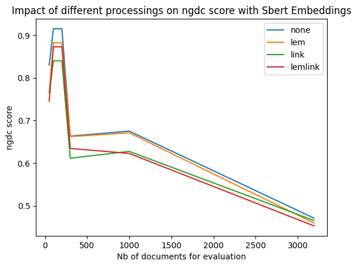

```python
plotResults(scores1,"Impact of different processings on ngdc score with Sbert Embeddings")
```

```python
scores2 = {"none":{},"lem":{},"link":{},"lemlink":{}}
nb = [50,100,200,300,1000,len(dicDoc)]
for i in nb:
  scores2["none"][str(i)]    = evaluateSimilarity(0,i,method='fasttext',lem=False,link=False)
  scores2["lem"] [str(i)]    = evaluateSimilarity(0,i,method='fasttext',lem=True,link=False)
  scores2["link"][str(i)]    = evaluateSimilarity(0,i,method='fasttext',lem=False,link=True)
  scores2["lemlink"][str(i)] = evaluateSimilarity(0,i,method='fasttext',lem=True,link=True)
```

```
mean none 0.3626340973223641
mean lem 0.38014147173945
mean link 0.36436148202585944
mean lemlink 0.3421449339575385
```

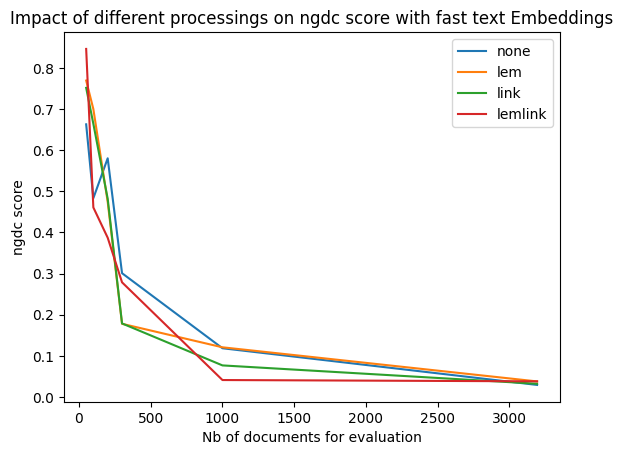

```python
plotResults(scores2,"Impact of different processings on ngdc score with fast text Embeddings")
```

The best pre processing is to keep all links and addresses and keep all original words. Since Fast text shows poor results, we will only try to thune SBert model deleting most frequent words in document and request.

#### **Delete most frequent words in documents**

```python
vocabDoc = AllVocab(dicDoc,lem=False,link=True)
vocabDoc = dict(sorted(vocabDoc.items(), key=lambda item: item[1],reverse=True))
```

```python
scores3 = {"0":{},"5":{},"10":{},"25":{},"40":{}}
nb = [50,100,200,300,1000,len(dicDoc)]
scores3["0"]=scores1["none"]
for i in nb:
  scores3["5"][str(i)]  = evaluateSimilarity(0,i,method='sbert',lem=False ,link=False,delWordsDoc=list(vocabDoc.keys())[:5])
  scores3["10"][str(i)] = evaluateSimilarity(0,i,method='sbert',lem=False ,link=False,delWordsDoc=list(vocabDoc.keys())[:10])
  scores3["25"][str(i)] = evaluateSimilarity(0,i,method='sbert',lem=False ,link=False,delWordsDoc=list(vocabDoc.keys())[:25])
  scores3["40"][str(i)] = evaluateSimilarity(0,i,method='sbert',lem=False ,link=False,delWordsDoc=list(vocabDoc.keys())[:40])
```

```
mean 0 0.7450483254656547
mean 5 0.7216788370473122
mean 10 0.7032461224319185
mean 25 0.7009319953855414
mean 40 0.6531697523887955
```

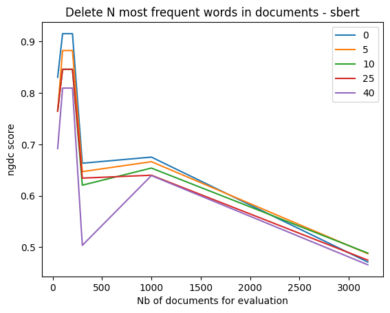

```python
plotResults(scores3,"Delete N most frequent words in documents - sbert")
```

Best on all corpus is to delete 5 or 10 words

#### **Delete most frequent words in requests**

```python
vocabReq = AllVocab(dicReq,lem=False,link=False)
vocabReq = dict(sorted(vocabReq.items(), key=lambda item: item[1],reverse=True))
```

```python
scores4 = {"0":{},"5":{},"10":{},"25":{},"40":{}}
nb = [50,100,200,300,1000,len(dicDoc)]
delWordsDoc=list(vocabDoc.keys())[:5]
for i in nb:
  scores4["0"][str(i)]  = evaluateSimilarity(0,i,method='sbert',lem=False ,link=False,delWordsDoc=delWordsDoc)
  scores4["5"][str(i)]  = evaluateSimilarity(0,i,method='sbert',lem=False ,link=False,delWordsDoc=delWordsDoc,delWordsReq=list(vocabReq.keys())[:5])
  scores4["10"][str(i)] = evaluateSimilarity(0,i,method='sbert',lem=False,link=False,delWordsDoc=delWordsDoc,delWordsReq=list(vocabReq.keys())[:10])
  scores4["25"][str(i)] = evaluateSimilarity(0,i,method='sbert',lem=False,link=False,delWordsDoc=delWordsDoc,delWordsReq=list(vocabReq.keys())[:25])
  scores4["40"][str(i)] = evaluateSimilarity(0,i,method='sbert',lem=False,link=False,delWordsDoc=delWordsDoc,delWordsReq=list(vocabReq.keys())[:40])
```

```
mean 0 0.7216788370473122
mean 5 0.7284573379391119
mean 10 0.7306760958742067
mean 25 0.7251202431672054
mean 40 0.7082803946753448
```

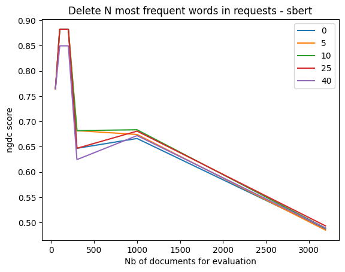

```python
plotResults(scores4,"Delete N most frequent words in requests - sbert")
```

*We can conclude that Sbert does Better embeddings, it doesnt really need much preprocessing to be efficient*

### **6.3 - Visualize results**

```python
nb = [50,100,200,300,1000,len(dicDoc)]
delWordsDoc=list(vocabDoc.keys())[:5]
#delWordsReq=list(vocabReq.keys())[:30]

scores_final,scorebm25=[],[]
for i in nb:
  scores_final.append(evaluateSimilarity(0,i,method="sbert",lem=False,link=False,delWordsDoc=delWordsDoc))#,delWordsReq=delWordsReq))
  scorebm25.append(ndgcScore_bm25(0,i))
```

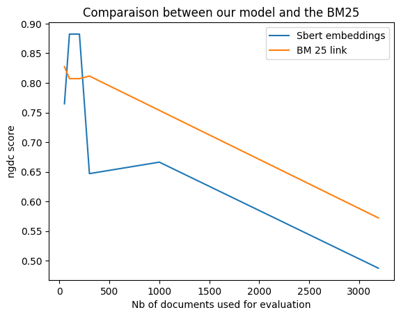

```python
plt.plot(nb,scores_final,label="Sbert embeddings")
plt.plot(nb,scorebm25,label="BM 25 link")
plt.title("Comparaison between our model and the BM25")
plt.xlabel("Nb of documents used for evaluation")
plt.ylabel("ngdc score")
plt.legend()
```

```python
print("Best ndgc score on corpus")
print(" - with Sbert : ",scores_final[-1])
print(" - with BM25  : ",scorebm25[-1])
```

```
Best ndgc score on corpus
 - with Sbert :  0.4873016183184893
 - with BM25  :  0.5721574606500178
```

## **7 User request**

```python
allDoc, allReq, allReqDoc = loadNFCorpus()
request = "deep fried foods may cause cancer in the latest study on dietary patterns and breast cancer risk among women , healthier eating was associated with eliminating three-quarters of the odds of breast cancer , whereas less healthy eating was associated with up to nearly eight times the odds . included in the unhealthy eating pattern was the consumption of deep-fried foods , which have previously been linked to breast cancer , pancreatic cancer , lung cancer , oral and throat cancers , esophageal cancer , and cancer of the voicebox . no deep fried foods ? what ’ s a southern belle to do ? instead of deep fried foods , how about the traditional southern diet , characterized by high intakes of cooked greens , beans , legumes , cabbage , sweet potatoes and cornbread , which may reduce the risk of invasive breast cancer significantly "
score_min = 0.6 #give a minimum score
```

```python
docTokens, docNames, docIndices = getTokenDoc(allDoc, allDoc,delWords=list(vocabDoc.keys())[:5],lem=False,link=False) #tokenize doc
reqToken = tokenizeDoc(request,lem=False,link=False) #tokenize Request
model         = SentenceTransformer('paraphrase-MiniLM-L6-v2') #call model
embeddingsDoc = sbertDoc(docTokens, model)  #embeddings on documents
embeddingsReq = sbert_embedding([" ".join(reqToken)], model) #embedding on request
doc_scores    = [cosine_similarity(embeddingsReq[0], doc) for doc in embeddingsDoc] #Get a score per document
```

```python
result={}
for i in range(len(doc_scores)):  #select corresponding documents
  if np.abs(doc_scores[i])>score_min:
    result[docNames[i]] = doc_scores[i]
result = dict(sorted(result.items(), key=lambda item: item[1],reverse=True))
```

```python
result
```

```
{'MED-4070': 0.6866002, 'MED-1151': 0.6112455, 'MED-3557': 0.60011595}
```

```python
print(dicDoc["MED-4070"])
```

```
intake fried meat risk cancer follow-up study finland pubmed ncbi abstract suggested mutagens fried meat involved cancer process relationships intake fried meat subsequent risk cancers sites studied num finnish men women num years age initially free cancer baseline study carried num cases cancer ide…
```

```python
save_path = '/content/drive/MyDrive/Colab Notebooks/'
notebook_name = 'final_NLP_project.ipynb'
html_name = 'final_NLP_project_Tissot_Pouxviel.html'

os.system(f'jupyter nbconvert --to html "{save_path}{notebook_name}" --output "{save_path}{html_name}"')
```

```
65280
```

```python
from google.colab import files
files.download(f'{save_path}{html_name}')
```

[output not shown]